# Lesson 2B: More about Vector

## Working with logical vectors

- **Logical vectors** are frequently used in data analysis to account for different conditions.

```r
# logical vector
c(TRUE, FALSE, FALSE, TRUE, TRUE)
c(T, F, F, T, T)
```

### Comparison operators

- A logical vector can be created using **comparison operators**.

| **Logical Operator** | **Description** |
| --- | --- |
| `<` | Less than |
| `<=` | Less than or equal to |
| `>` | Greater than |
| `>=` | Greater than or equal to |
| `==` | Exactly equal to |
| `!=` | Not equal to |

```r
x <- c(-2, -1, 0, 1, 2, 3)

x < 0     # less than

x <= 0    # less than or equal to

x > 0     # greater than

x >= 0    # greater than or equal to

x == 0    # exactly equal to

x != 0    # not equal to
```

**Hands-On**

Consider daily high temperatures in celsius over two weeks. Write R code to answer the following questions:

- Which days had temperatures **at least 30°C**?
- Which days had temperatures **exactly equal to 19°C**?
- Which days had temperatures **below 20°C**?
- Which days had temperatures **greater than 25°C**?
- Which days had temperatures **at most 22°C**?

```r
# Daily high temperatures over two weeks
temps <- c(
  Mon02 = 18, Tue03 = 21, Wed04 = 19, Thu05 = 25, Fri06 = 27, Sat07 = 30, Sun08 = 22,
  Mon09 = 20, Tue10 = 16, Wed11 = 24, Thu12 = 28, Fri13 = 31, Sat14 = 29, Sun15 = 17
)
```

**Answer:**

```r
### R code here
```

### The `sum()` function

- Applying the `sum()` function to a logical vector gives the number of `TRUE` values.
- Recall that implicit coercion turns logical values to $1$’s and $0$’s.

```r
v <- c(TRUE, FALSE, FALSE, TRUE, TRUE)
sum(v)
```

```
#> [1] 3
```

**Hands-On**

Try the following R code and see what it returns.

```r
x <- c(-2, -1, 0, 1, 2, 3)

sum(x < 0)

sum(x <= 0)

sum(x > 0)

sum(x >= 0)

sum(x == 0)

sum(x != 0)
```

**Hands-On**

Consider daily high temperatures in celsius over two weeks. Write R code to answer the following questions:

- How many days had temperatures **below 18°C**?
- How many days had temperatures **greater than 26°C**?
- How many days had temperatures **at most 21°C**?
- How many days had temperatures **at least 28°C**?

```r
# Daily high temperatures over two weeks
temps <- c(
  Mon02 = 18, Tue03 = 21, Wed04 = 19, Thu05 = 25, Fri06 = 27, Sat07 = 30, Sun08 = 22,
  Mon09 = 20, Tue10 = 16, Wed11 = 24, Thu12 = 28, Fri13 = 31, Sat14 = 29, Sun15 = 17
)
```

**Answer:**

```r
### R code here
```

### The `which()` function

- The `which()` function returns the indices of `TRUE` values.

**Hands-On**

Try the following R code and see what it returns.

```r
x <- c(-2, -1, 0, 1, 2, 3)

which(x < 0)

which(x > 0)

which(x <= 0)

which(x >= 0)

which(x == 0)

which(x != 0)
```

**Answer:**

```r
### R code here
```

### Relational operators

- **Relational operators** are powerful tools to combine conditional statements

| **Relationship Operator** | **Description** |
| --- | --- |
| & | and |
| \| | or |
| ! | not |

**Hands-On**

Try the following R code and see what it returns.

```r
x <- c(1, 2, 3, 4, 5, 6, 7, 8, 9)

x > 3 & x < 8

!(x > 3 & x < 8)
```

**Answer:**

```r
### R code here
```

**Hands-On**

Try the following R code and see what it returns.

```r
x <- c(1, 2, 3, 4, 5, 6, 7, 8, 9)

x < 4 | x > 6

!(x < 4 | x > 6)
```

**Answer:**

```r
### R code here
```

**Hands-On**

Consider daily high temperatures in celsius over two weeks. Write R code to answer the following questions:

- Which days had temperatures **at least 20°C and at most 25°C**?
- Which days had temperatures **below 18°C or above 28°C**?

```r
# Daily high temperatures over two weeks
temps <- c(
  Mon02 = 18, Tue03 = 21, Wed04 = 19, Thu05 = 25, Fri06 = 27, Sat07 = 30, Sun08 = 22,
  Mon09 = 20, Tue10 = 16, Wed11 = 24, Thu12 = 28, Fri13 = 31, Sat14 = 29, Sun15 = 17
)
```

**Answer:**

```r
### R code here
```

## Subsetting

- Certain elements of a vector can be subsetted using the brackets `[]`

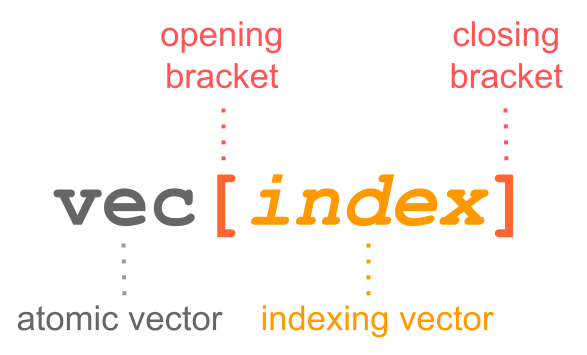

- Subsetting can be done using one of the following indexing methods:
  - Numeric indexing
  - Logical indexing
  - Character indexing (if the vector has names; not covered here)

## Numeric indexing

- Numeric indexing means telling R the specific indices to return values.

```r
#       1   2   3   4   5   6   7
v <- c(70, 66, 82, 85, 78, 90, 73)

v[1]            # 1st value

v[4]            # 4th value

v[length(v)]    # last value, 7th value

v[320]          # Not available
```

- Numeric indexing can also use a vector of multiple indices.

```r
#       1   2   3   4   5   6   7
v <- c(70, 66, 82, 85, 78, 90, 73)

v[2:5]                 # at 2nd, 3rd, 4th, 5th

v[5:2]                 # at 5th, 4th, 3rd, 2nd

v[c(3, 1, 3, 5, 2)]    # at 3rd, 1st, 3rd, 5th, 2nd
```

- Note that negative indices mean all but the specified indices.

```r
#       1   2   3   4   5   6   7
v <- c(70, 66, 82, 85, 78, 90, 73)

v[-1]                    # all but 1st value

v[-c(2, 5)]              # all but 2nd and 5th values

v[-(1:4)]                # all but 1st to 4th values

v[-1:4]                  # error!
```

**Hands-On**

Write R code to return the following in `v`

- The second value
- The sixth value
- The first and last values.
- The values at positions 3 through 6
- The values at positions 6 through 3
- The values at positions 1, 4, and 7
- All values except the first.
- All values except the last two.
- All values except positions 2 and 6.

```r
#       1   2   3   4   5   6   7
v <- c(70, 66, 82, 85, 78, 90, 73)
```

**Answer:**

```r
### R code here
```

## Logical Indexing

- **Logical indexing** means telling R which values to return and which values not to return.
- With logical indexing, `TRUE` will retain the elements, while `FALSE` will discard the elements.
- Logical indexing is powerful because it allows for subsetting with conditions.

```r
#       1   2   3   4   5   6   7
v <- c(70, 66, 82, 85, 78, 90, 73)

v[c(TRUE, FALSE, FALSE, FALSE, FALSE, TRUE, FALSE)]    # 1st, 6th

v[c(FALSE, TRUE, TRUE, TRUE, FALSE, FALSE, FALSE)]     # 2nd, 3rd, 4th

v[v > 80]    # those values greater than 80
```

**Hands-On**

Use numeric and logical indexing to subset

- `66 82 90 73`
- `70 66 78 73`

```r
#       1   2   3   4   5   6   7
v <- c(70, 66, 82, 85, 78, 90, 73)
```

**Hands-On**

The monthly cost for a stand-alone drug plan varies from plan to plan and from state to state. The vector `cost` gives the premium for the plan with the lowest cost for each state in 2005 (excludes District of Columbia). Write R code using `cost` and `state.name` to find state(s) with a monthly premium

- Less than or equal to $\$5$
- Greater than $\$10$
- Between $\$5$ and $\$10$ (exclusive)
- Exactly equal to $\$1.87$
- At most $\$7$
- At least $\$15$
- To be the smallest
- To be the largest

```r
?state.name

cost <- c(
  14.08, 20.05, 6.14, 10.31, 5.41, 8.62, 7.32,
  6.44, 10.35, 17.91, 17.18, 6.33, 13.32, 12.30, 1.87,
  9.48, 12.30, 17.06, 19.60, 6.44, 7.32, 13.75, 1.87,
  11.60, 10.29, 1.87, 1.87, 6.42, 19.60, 4.43, 10.65,
  4.10, 13.27, 1.87, 14.43, 10.07, 6.93, 10.14, 7.32,
  16.57, 1.87, 14.08, 10.31, 6.33, 7.32, 8.81, 6.93,
  10.14, 11.42, 1.87
)
```

## Useful functions for vectors

Given a vector,

- `head()` returns its first few elements
- `tail()` returns its last few elements
- `sort()` returns its sorted version in increasing or decreasing order
- `order()` returns the indices
- `rev()` returns the reversed vector
- `unique()` returns a vector of its unique elements
- `table()` shows unique elements and their frequencies

**Hands-On**

The monthly cost for a stand-alone drug plan varies from plan to plan and from state to state. The vector `cost` gives the premium for the plan with the lowest cost for each state in 2005 (excludes District of Columbia). Try the following R code and see what it returns.

```r
cost <- c(
  14.08, 20.05, 6.14, 10.31, 5.41, 8.62, 7.32,
  6.44, 10.35, 17.91, 17.18, 6.33, 13.32, 12.30, 1.87,
  9.48, 12.30, 17.06, 19.60, 6.44, 7.32, 13.75, 1.87,
  11.60, 10.29, 1.87, 1.87, 6.42, 19.60, 4.43, 10.65,
  4.10, 13.27, 1.87, 14.43, 10.07, 6.93, 10.14, 7.32,
  16.57, 1.87, 14.08, 10.31, 6.33, 7.32, 8.81, 6.93,
  10.14, 11.42, 1.87
)

head(cost)    # head(cost, n = 6)

tail(cost)    # tail(cost, n = 6)

sort(cost)

sort(cost, decreasing = TRUE)

order(cost)

order(cost, decreasing = TRUE)

rev(cost)
```

**Answer:**

```r
### R code here
```

**Hands-On**

The vectors `scores` and `grades` contain exam scores and the corresponding letter grades for students in a statistics class. Write R code to:

- Show the first and last few exam scores
- Sort the exam scores in decreasing order
- Show unique letter grades of students in this class and their frequencies

```r
scores <- c(
  88, 92, 75, 84, 91, 67, 73, 88, 95, 78,
  82, 90, 69, 74, 85, 88, 93, 77, 81, 89,
  94, 72, 68, 86, 80, 76, 83, 88, 91, 79
)

grades <- c(
  'B', 'A', 'C', 'B', 'A', 'D', 'C', 'B', 'A', 'C',
  'B', 'A', 'D', 'C', 'B', 'B', 'A', 'C', 'B', 'B',
  'A', 'C', 'D', 'B', 'B', 'C', 'B', 'B', 'A', 'C'
)
```

**Answer:**

```r
### R code here
```